# Getting Started

This short guide shows you how to run and edit the course notebooks on your own computer, or entirely in the browser if you prefer.  
*(Total setup time: ~10 minutes if you’re new to Python.)*

[figure not shown]

## Setting up your local environment

The easiest and safest way to get everything you need is via the Anaconda distribution, which includes Python and common scientific libraries like numpy, matplotlib, networkx, and scipy.

**No‑install option:** Use Google Colab (see last section) and skip everything else (we recommend trying the Anaconda route first for full flexibility and offline use).

**Steps:**

1. Go to: https://www.anaconda.com/products/individual
2. Download the 64-bit graphical installer for your operating system (Windows, macOS, or Linux)
3. Run the installer and accept the default settings
4. Once installed, open Anaconda Navigator or launch a Jupyter Notebook from the terminal using:

```
jupyter notebook  # or: jupyter lab
```

## Workshop notebooks

All .ipynb notebooks will be provided via LMS (you don’t need Git or GitHub access).

Jupyter notebooks (.ipynb files) let you combine code, text, images, and equations in a single interactive document. To add notes, explanations, or formatted content use Markdown cells (via Cell → Cell Type → Markdown in the menu).

You can include:

- Text with headings and bullet points
- LaTeX-style equations
- Images, links, and more

There are some useful keyboard shortcuts here: https://cheatography.com/weidadeyue/cheat-sheets/jupyter-notebook/pdf/

**Each week:**

1. Download the .ipynb files from LMS
2. Open them using Jupyter Notebook (installed with Anaconda)
3. Run and modify the code in-place
- A browser tab will open.
- Navigate to any `.ipynb` notebook (e.g. `week01/intro.ipynb`).
- Run a cell with **Shift + Return**.

## Zero‑Install Option — Google Colab

If you can’t install locally:

1. Go to https://colab.research.google.com
2. Click **File ▸ Upload Notebook** and choose any `.ipynb` from the repo.
3. Run cells directly in your browser (Python 3 with common libraries pre‑installed).

```
✅ All core packages imported successfully!
```

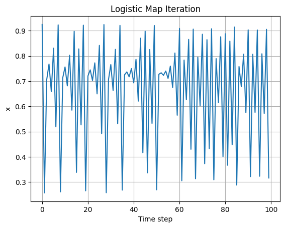

```python
# Test cell: Basic setup check

import numpy as np
import matplotlib.pyplot as plt

print("✅ All core packages imported successfully!")

# Simple plot: logistic map
r = 3.7
x = 0.5
xs = []
for _ in range(100):
    x = r * x * (1 - x)
    xs.append(x)

plt.plot(xs)
plt.title("Logistic Map Iteration")
plt.xlabel("Time step")
plt.ylabel("x")
plt.grid(True)
plt.show()
```

# Let's Code!

> *"The purpose of computing is insight, not numbers."* - Richard Hamming

It can be ugly. That's ok, you are not software engineers or game developers, you are mathematicians using code as a tool for thinking.

Remember that there are countless examples of Python online if there is a coding task that you find difficult. Learning how to find the examples most useful for you and working alongside ChatGPT etc are important skills to develop.

## Best practices

Keep code simple and organised

Follow best practices (modularise sections and create function blocks, use informative comments, test as you go...). See here for some elaboration: https://www.thinkful.com/blog/coding-best-practices/

## Pseudo-code

Start with pseudo-code!

Pseudo-code is language-agnostic so you to outline the logic and concentrate on the problem-solving process itself, rather than getting bogged down in sytax specifics.

You can write pseudo-code in many ways, as long as it is unambiguous.

For example:

```
// Input: Two numbers, num1 and num2

// Step 1: Read the first number (num1)
Read num1

// Step 2: Read the second number (num2)
Read num2

// Step 3: Calculate the sum of num1 and num2
sum = num1 + num2

// Step 4: Display the result
Display sum
```

An alternative:

```
          +-----------------+
          | Start           |
          +-----------------+
                   |
                   |
          +--------v--------+
          | Read num1       |
          +--------+--------+
                   |
                   |
          +--------v--------+
          | Read num2       |
          +--------+--------+
                   |
                   |
          +--------v--------+
          |    sum = num1   |
          |    + num2       |
          +--------+--------+
                   |
                   |
          +--------v--------+
          |  Display sum    |
          +--------+--------+
                   |
                   |
          +--------v--------+
          |    Stop         |
          +-----------------+
```

Another alternative:

```
1. Start the program.
2. Prompt the user to enter the first number (num1).
3. Read the value of num1 from the user.
4. Prompt the user to enter the second number (num2).
5. Read the value of num2 from the user.
6. Calculate the sum of num1 and num2, and store it in a variable called sum.
7. Display the value of sum to the user.
8. End the program.
```